# Sistemas y Señales Biomédicos

Laboratorio 002: El electrocardiograma. Fundamentos Teóricos.

SYSB

Autores/as

Ph.D. Jenny Carolina Castiblanco

Ph.D. Pablo Eduardo Caicedo Rodríguez

Fecha de publicación

4 de marzo de 2025

# **Actividad de Aprendizaje: Introducción teórica al electrocardiograma**

El electrocardiograma (ECG o EKG) es una grabación de la actividad eléctrica cardíaca en la superficie de la piel, durante un período de tiempo determinado. En cada ciclo cardíaco, un corazón sano presenta una secuencia de señales eléctricas que se generan en el nodo sinoauricular y se distribuyen en el corazón hasta alcanzar los ventrículos. Estas señales tienen una forma característica que se muestra en la figura 1.

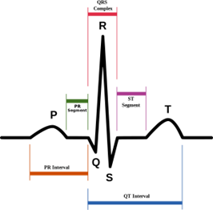

Figura 1. ECG durante un ciclo cardíaco normal

A través de un ECG, un profesional de la salud entrenado es capaz de obtener información relevante sobre el funcionamiento del corazón; por ejemplo, se puede determinar la frecuencia cardíaca, la presencia de daño en el músculo cardíaco, los efectos de medicamentos y la función de marcapasos implantados.

## **Objetivo de Aprendizaje**

Los estudiantes conocerán las principales teorías concernientes a la generación del electrocardiograma y su relación con el funcionamiento del corazón.

## **Duración**

4.5 horas

## **Materiales**

- Computador.
- [Zheng, J., Zhang, J., Danioko, S. et al. A 12-lead electrocardiogram database for arrhythmia research covering more than 10,000 patients. Sci Data 7, 48 (2020). https://doi.org/10.1038/s41597-020-0386-x](https://www.nature.com/articles/s41597-020-0386-x)
- [Dataset](https://physionet.org/content/ecg-arrhythmia/1.0.0/)
- [Zheng, J., Chu, H., Struppa, D. et al. Optimal Multi-Stage Arrhythmia Classification Approach. Sci Rep 10, 2898 (2020). https://doi.org/10.1038/s41598-020-59821-7](https://www.nature.com/articles/s41598-020-59821-7)

# **Parte 1: Revisión de la literatura**

## **Actividad 1: Revisión al electrocardiograms**

1. ¿Qué es un electrocardiograma (ECG) y cuál es su importancia en el diagnóstico clínico?
2. ¿Qué información electrofisiológica proporciona un ECG y cómo se relaciona con la actividad del corazón?
3. ¿Qué es una derivación (lead) en el contexto de un ECG y cuál es su función?
4. ¿Cuántas derivaciones existen en un ECG estándar y cómo se clasifican?
5. Observe la Figura 1 proporcionada y determine a qué derivación corresponde el diagrama mostrado. Justifique su respuesta.
6. ¿Qué es una arritmia y qué tipos existen? Describa las características de cada tipo de arritmia.

## **Actividad 2: Análisis del articulo**

1. ¿Cuáles son las principales clases de arritmias que el artículo estudia y cómo se agrupan?
2. ¿Qué impacto tienen las arritmias en la salud pública según el artículo? Mencione datos estadísticos relevantes.
3. ¿Por qué es importante mejorar la precisión en la clasificación automática de arritmias?
4. ¿Cuáles son las principales fuentes de ruido en una señal de ECG y qué técnicas se utilizaron en el artículo para reducirlas?
5. ¿Por qué se aplicó normalización a las señales ECG? ¿Qué impacto tuvo en la clasificación? Explique el método de normalización.
6. ¿Cuáles son las principales características extraídas de la señal ECG en este estudio?
7. ¿Por qué es importante la selección de características para el entrenamiento de un algoritmo de clasificación?

## **Actividad 3: Análisis de la base de datos**

1. ¿Cuáles fueron los criterios de selección de los pacientes?
2. ¿Cuántos registros de ECG se recopilaron en total y qué duración tienen las señales analizadas?
3. ¿Cómo se realizó la toma de datos del ECG? Especifique el número de derivaciones, la duración del registro y la frecuencia de muestreo.
4. ¿Cuáles fueron las características demográficas de la población estudiada? Describa la distribución por edad y género.
5. ¿Cuál fue la prevalencia de cada tipo de arritmia en la base de datos? ¿Qué arritmias fueron las más frecuentes y cuáles fueron las menos comunes?

## **Criterios de Evaluación**

| **Criterio** | **Nivel Excelente (5.0 - 4.5)** | **Nivel Satisfactorio (4.4 - 3.5)** | **Nivel Aceptable (3.4 - 2.5)** | **Nivel Deficiente (<2.5)** | **Peso (%)** |
| --- | --- | --- | --- | --- | --- |
| **Comprensión teórica del ECG y su relevancia clínica** | Explica de manera clara y detallada la importancia del ECG, su función diagnóstica y la información electrofisiológica que proporciona. Responde con precisión todas las preguntas teóricas. | Responde la mayoría de las preguntas con claridad, pero algunas respuestas pueden carecer de profundidad o detalles. | Responde las preguntas de manera parcial o con imprecisiones conceptuales. Falta claridad en algunos conceptos. | Respuestas incompletas o con errores fundamentales en la comprensión del ECG y su relevancia. | 20% |
| **Análisis del artículo de Zheng et al.** | Identifica y sintetiza correctamente las clases de arritmias, impacto en salud pública, técnicas de reducción de ruido y normalización. Argumenta con evidencia del artículo. | Presenta un buen análisis, aunque algunas respuestas carecen de profundidad o precisión. Uso adecuado pero limitado de la evidencia. | Muestra dificultad en identificar o explicar correctamente algunos conceptos clave del artículo. | Análisis deficiente, respuestas vagas o incorrectas, falta de relación con el artículo. | 20% |
| **Análisis de la base de datos de ECG** | Describe con precisión los criterios de selección, número de registros, condiciones de adquisición y características demográficas. Utiliza correctamente los datos del artículo. | Explica la mayoría de los aspectos, aunque con algunas omisiones o falta de precisión en los datos. | Responde parcialmente, con confusión en algunos aspectos metodológicos o demográficos. | No logra describir correctamente los criterios de la base de datos o presenta errores graves en su interpretación. | 20% |
| **Justificación y análisis de derivaciones** | Identifica correctamente la derivación del ECG mostrado en la Figura 1, justificando con base en conocimientos teóricos. | Identifica la derivación con una justificación aceptable, aunque podría ser más clara. | Presenta una identificación incorrecta o incompleta con una justificación débil. | No justifica o identifica erróneamente la derivación. | 15% |
| **Presentación y redacción del informe** | Informe bien estructurado, sin errores gramaticales o de formato. Uso adecuado de referencias. Argumentación clara y precisa. | Informe organizado, aunque con algunos errores menores de gramática o formato. Argumentación adecuada. | Presentación con errores de redacción y formato. Explicaciones poco estructuradas. | Informe desorganizado, con errores graves de gramática y sin referencias adecuadas. | 15% |
| **Participación y trabajo en equipo** | Demuestra alto compromiso y participación en la sesión de laboratorio. Contribuye activamente al desarrollo del informe. | Participa en la mayoría de las actividades, aunque con algunas intervenciones limitadas. | Participa de forma esporádica o depende en exceso del grupo para completar las actividades. | No participa o su aporte al equipo es mínimo. | 10% |

**Total: 100% puntos**.